# PA1_template.Rmd

Caio Alves

9/18/2018

# Peer-graded Assignment: Course Project 1

It is now possible to collect a large amount of data about personal movement using activity monitoring devices such as a Fitbit, Nike Fuelband, or Jawbone Up. These type of devices are part of the “quantified self” movement – a group of enthusiasts who take measurements about themselves regularly to improve their health, to find patterns in their behavior, or because they are tech geeks. But these data remain under-utilized both because the raw data are hard to obtain and there is a lack of statistical methods and software for processing and interpreting the data.

This assignment makes use of data from a personal activity monitoring device.

## Observations

- I’ve hide all library loads from HTML/Markdown report for reading purposes

# Analysis

## Loading and preprocessing the data

### Load the Data

```r
rawData <- read.csv("activity.csv")
```

### Process/transform the data (if necessary) into a format suitable for your analysis

Creating variable without NA steps

```r
# Using dplyr library
data <- rawData %>% filter(!is.na(steps))
```

## What is mean total number of steps taken per day?

For this part of the assignment, I will ignore the missing values in the dataset.

### Calculate the total number of steps taken per day

```r
totalSteps <- aggregate(data$steps, list(date = data$date), sum)
print(totalSteps)
```

```
##          date     x
## 1  2012-10-02   126
## 2  2012-10-03 11352
## 3  2012-10-04 12116
## 4  2012-10-05 13294
## 5  2012-10-06 15420
## 6  2012-10-07 11015
## 7  2012-10-09 12811
## 8  2012-10-10  9900
## 9  2012-10-11 10304
## 10 2012-10-12 17382
## 11 2012-10-13 12426
## 12 2012-10-14 15098
## 13 2012-10-15 10139
## 14 2012-10-16 15084
```

[output cut: 39 more lines]

### Make a histogram of the total number of steps taken each day

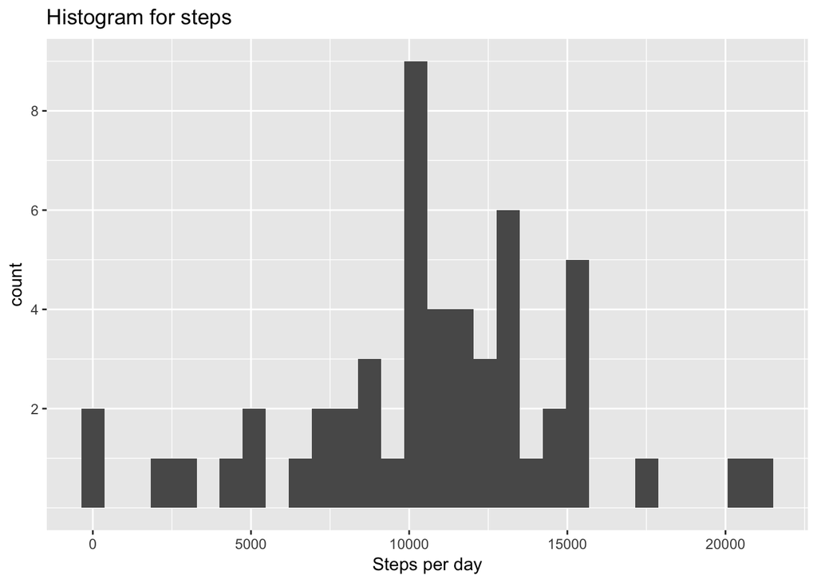

```r
histogram <- ggplot(data = totalSteps, aes(totalSteps$x)) + geom_histogram() + labs(x = "Steps per day", title = "Histogram for steps") + scale_y_continuous(breaks = (1:5)*2)
print(histogram)
```

```r
meanSteps <- aggregate(data$steps, list(date = data$date), mean)
print(meanSteps)
```

```
##          date          x
## 1  2012-10-02  0.4375000
## 2  2012-10-03 39.4166667
## 3  2012-10-04 42.0694444
## 4  2012-10-05 46.1597222
## 5  2012-10-06 53.5416667
## 6  2012-10-07 38.2465278
## 7  2012-10-09 44.4826389
## 8  2012-10-10 34.3750000
## 9  2012-10-11 35.7777778
## 10 2012-10-12 60.3541667
## 11 2012-10-13 43.1458333
## 12 2012-10-14 52.4236111
## 13 2012-10-15 35.2048611
## 14 2012-10-16 52.3750000
```

[output cut: 39 more lines]

```r
medianSteps <- aggregate(data$steps, list(date = data$date), median)
print(medianSteps)
```

```
##          date x
## 1  2012-10-02 0
## 2  2012-10-03 0
## 3  2012-10-04 0
## 4  2012-10-05 0
## 5  2012-10-06 0
## 6  2012-10-07 0
## 7  2012-10-09 0
## 8  2012-10-10 0
## 9  2012-10-11 0
## 10 2012-10-12 0
## 11 2012-10-13 0
## 12 2012-10-14 0
## 13 2012-10-15 0
## 14 2012-10-16 0
```

[output cut: 39 more lines]

## What is the average daily activity pattern?

### Make a time series plot of the 5-minute interval (x-axis) and the average number of steps taken, averaged across all days (y-axis)

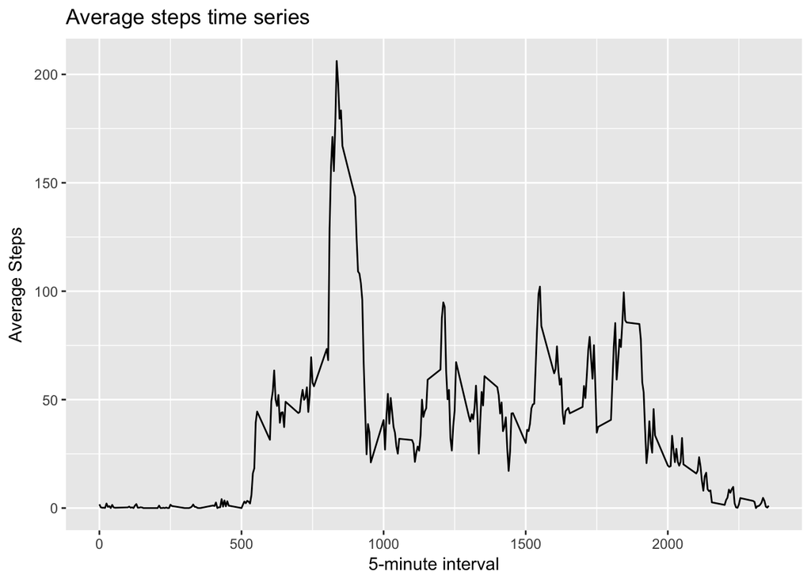

```r
timeSeriesData <- aggregate(data$steps, list(interval = data$interval), mean)
timeSeries <- ggplot(data = timeSeriesData, aes(x = interval, y = x)) + geom_line() + labs(x = "5-minute interval", y = "Average Steps", title = "Average steps time series")
print(timeSeries)
```

### Which 5-minute interval, on average across all the days in the dataset, contains the maximum number of steps?

```r
maxStepsInteval <- timeSeriesData %>% filter(x == max(x))
print(maxStepsInteval)
```

```
##   interval        x
## 1      835 206.1698
```